# Baseball Salary Analysis

Andrew Crater

2024-04-29

### Part 1: Visualize the data

The first step in any balanced data analysis is to view and visualize the data, in order to get a better idea of what is going on with the data.

```r
data <- read.csv("Final-player-salary.csv")
head(data, 6)
```

```
##   rank            Name Team POS     Salary        Years Total.Value Avg.Annual
## 1    1      Mike Trout  LAA  OF 34,083,333  6 (2015-20) 144,500,000 24,083,333
## 2    2 Clayton Kershaw  LAD  SP 34,000,000  7 (2014-20) 215,000,000 30,714,285
## 3    3    Zack Greinke  ARI  SP 31,954,483  6 (2016-21) 206,500,000 34,416,666
## 4    4  Miguel Cabrera  DET  1B 30,000,000 10 (2014-23) 292,000,000 29,200,000
## 5    5     David Price  BOS  SP 30,000,000  7 (2016-22) 217,000,000 31,000,000
## 6    6    Jake Arrieta  PHI  SP 30,000,000  3 (2018-20)  75,000,000 25,000,000
```

```r
data$Salary <- trimws(gsub(',', "", data$Salary, fixed = T))
data$Salary <- as.numeric(data$Salary)
data$Total.Value <- trimws(gsub(',', "", data$Total.Value, fixed = T))
data$Total.Value <- as.numeric(data$Total.Value)
data$Avg.Annual <- trimws(gsub(',', "", data$Avg.Annual, fixed = T))
data$Avg.Annual <- as.numeric(data$Avg.Annual)
```

We could see from the output of our head() function that the numeric values in our data were actually of data type so we needed to clean the data in order to be able to use it.

The years data is difficult to use, since it includes the years included on the contract, which is difficult to read in a useful way, so we will clean it such that it will essentially function as “contract length” instead, giving us a way to use it as a multilevel factor.

```r
data$Years <- gsub(" \\(.*\\)", "", data$Years)
data$Years <- as.numeric(data$Years)
head(data, 6)
```

```
##   rank            Name Team POS   Salary Years Total.Value Avg.Annual
## 1    1      Mike Trout  LAA  OF 34083333     6   144500000   24083333
## 2    2 Clayton Kershaw  LAD  SP 34000000     7   215000000   30714285
## 3    3    Zack Greinke  ARI  SP 31954483     6   206500000   34416666
## 4    4  Miguel Cabrera  DET  1B 30000000    10   292000000   29200000
## 5    5     David Price  BOS  SP 30000000     7   217000000   31000000
## 6    6    Jake Arrieta  PHI  SP 30000000     3    75000000   25000000
```

Now that we have data types representative of numeric values, we can proceed with graphing the data.

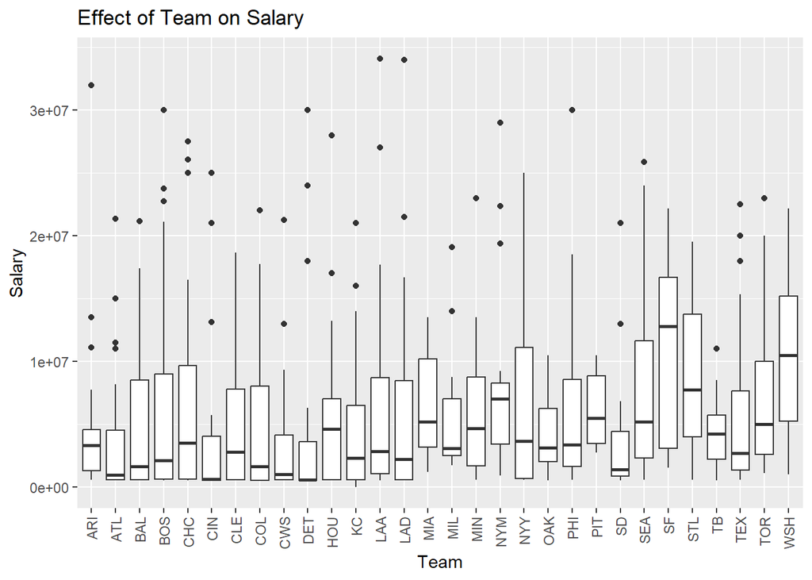

```r
factors <- c("Team", "POS", "Years", "Total.Value", "Avg.Annual")
data[,factors] <- lapply(data[,factors], as.factor)
library(ggplot2)
team.plt <-qplot(Team, Salary, data=data, geom ="boxplot")
team.plt+theme(axis.text.x = element_text(angle = 90, vjust = 0.5, hjust=1))+ggtitle("Effect of Team on Salary")
```

We can see from this visual representation that team does seem to have an effect on mean salary. We can use a similar methodology to compare the effect of position on salary.

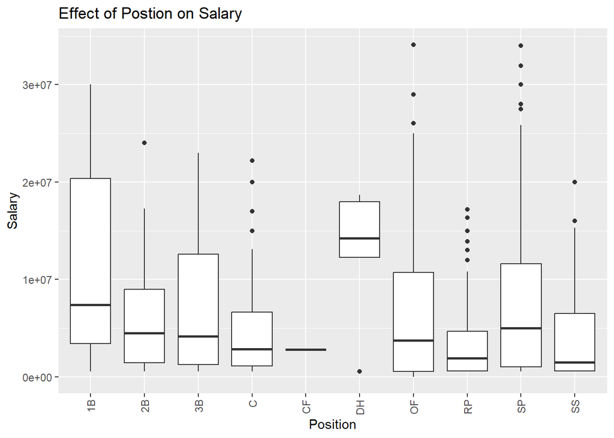

```r
pos.plt <-qplot(POS, Salary, data=data, geom ="boxplot")
pos.plt+theme(axis.text.x = element_text(angle = 90, vjust = 0.5, hjust=1))+ggtitle("Effect of Postion on Salary")+xlab("Position")
```

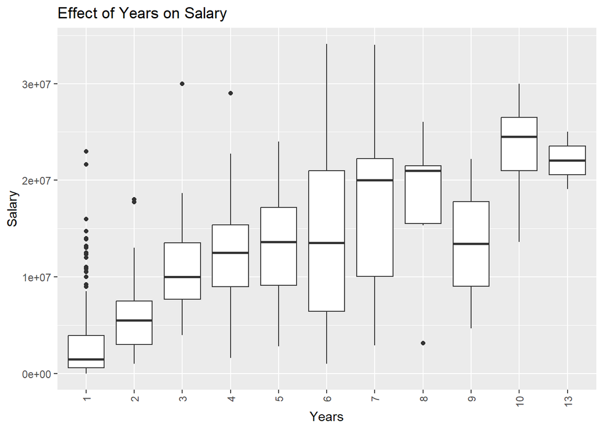

```r
years.plt <-qplot(Years, Salary, data=data, geom ="boxplot")
years.plt+theme(axis.text.x = element_text(angle = 90, vjust = 0.5, hjust=1))+ggtitle("Effect of Years on Salary")+xlab("Years")
```

We now have a pretty good idea that our independent variables likely have an impact on salary, so we can proceed to modeling with some idea of what our results may look like.

### Part 2: Modeling the data

Now that we have a more general idea of how the data should look, we can proceed to modeling the data, and see if the results back up what we think.

```r
salary.aov <- aov(Salary~Team*POS*Years, data = data)
summary(salary.aov)
```

```
##                 Df    Sum Sq   Mean Sq F value   Pr(>F)
## Team            29 1.962e+15 6.767e+13   8.465  < 2e-16 ***
## POS              9 3.193e+15 3.548e+14  44.382  < 2e-16 ***
## Years           10 1.255e+16 1.255e+15 156.928  < 2e-16 ***
## Team:POS       194 4.318e+15 2.226e+13   2.785 9.61e-15 ***
## Team:Years     101 3.623e+15 3.587e+13   4.487  < 2e-16 ***
## POS:Years       13 5.562e+14 4.279e+13   5.352 1.57e-08 ***
## Team:POS:Years  11 2.633e+14 2.393e+13   2.994 0.000905 ***
## Residuals      260 2.078e+15 7.994e+12
## ---
## Signif. codes:  0 '***' 0.001 '**' 0.01 '*' 0.05 '.' 0.1 ' ' 1
```

Based on this anova model, we can verify that our hypotheses that we made following our visualizations. Based on the very small p-values from our anova model, we have statistical evidence to reject the null hypotheses and say that Position, Team and Years definitely have significant impact on the mean salary of players.

One thing that may be helpful is visualizing some of the effects via an interaction plot, so we will do that in the next part before proceeding.

### Part 3: Interaction Visualization

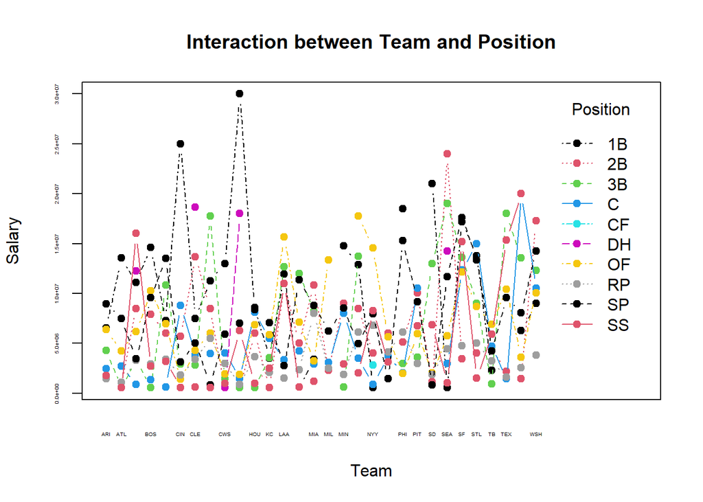

```r
library(ggplot2)
par(cex.axis=.3)
with(data, interaction.plot(Team, POS, Salary, type = "b", col = 1:11, pch = 19, fixed=T, xlab = "Team", ylab = "Salary", trace.label = "Position"))
title(main="Interaction between Team and Position")
```

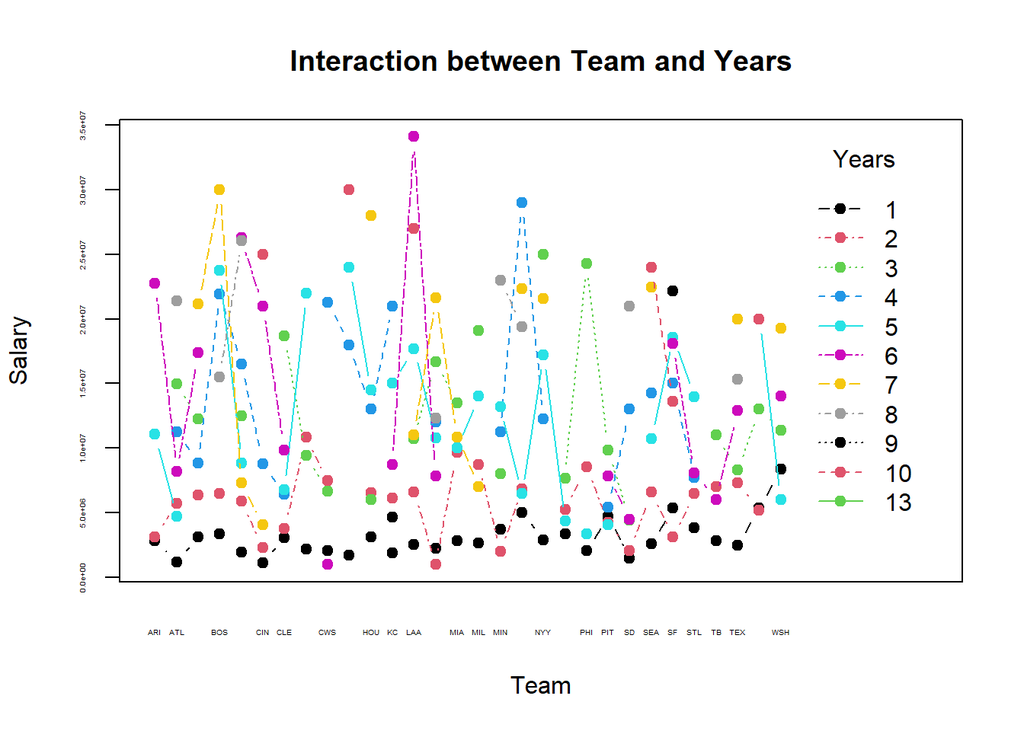

```r
with(data, interaction.plot(Team, Years, Salary, type = "b", col = 1:11, pch = 19, fixed=T, xlab = "Team", ylab = "Salary", trace.label = "Years"))
title(main="Interaction between Team and Years")
```

As we can see from both of these plots, there is interaction between the variables since the lines on our interaction plot regularly cross each other.

#### Three Way Interaction

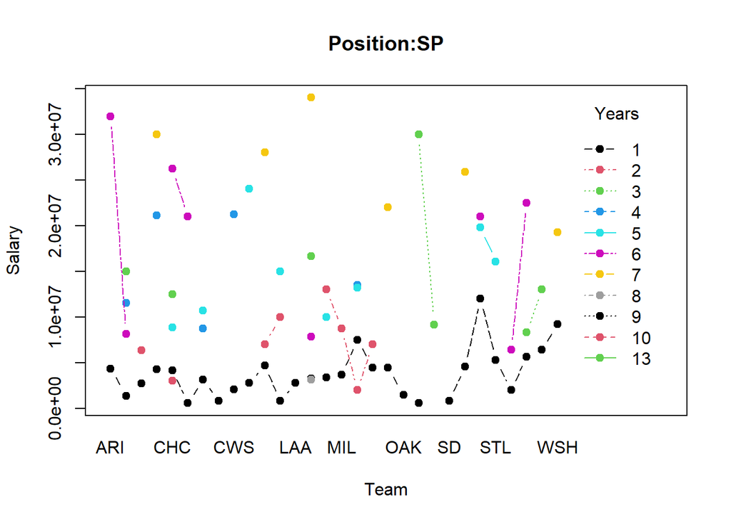

```r
library(magrittr)
library(dplyr)
pos.sp <- dplyr::filter(data, POS=="SP")


with(pos.sp, interaction.plot(Team, Years, Salary, type="b", col=1:13, pch=19, fixed = T, xlab="Team", ylab = "Salary", trace.label = "Years"))
title(main = "Position:SP")
```

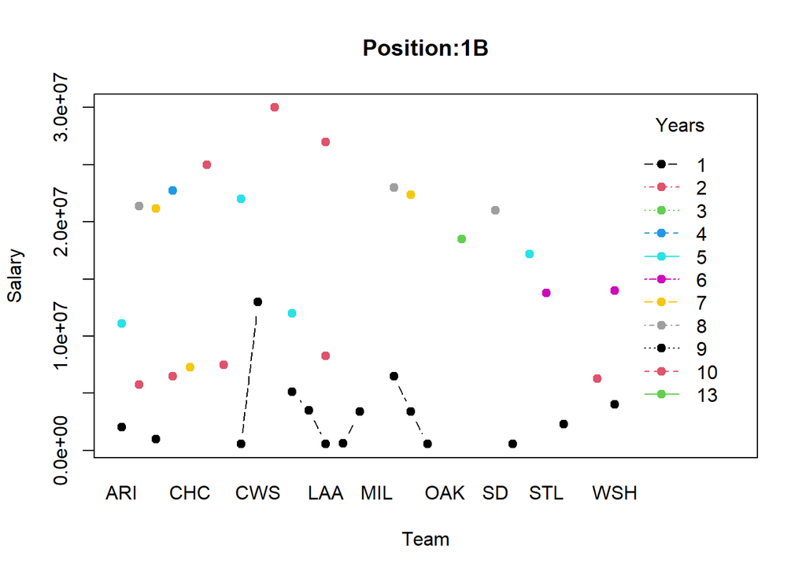

```r
pos.sp <- dplyr::filter(data, POS=="1B")


with(pos.sp, interaction.plot(Team, Years, Salary, type="b", col=1:13, pch=19, fixed = T, xlab="Team", ylab = "Salary", trace.label = "Years"))
title(main = "Position:1B")
```

We can see from the above graphs some examples of the three way interaction as well. Since the lines are not parallel even when we isolate for one position, this implies that all 3 factors have interaction with one another.

### Part 4: Residual Analysis

Another thing we must do when using an anova test is to examine the residuals of our model in order to determine the normality and homoscedasticity assumptions.

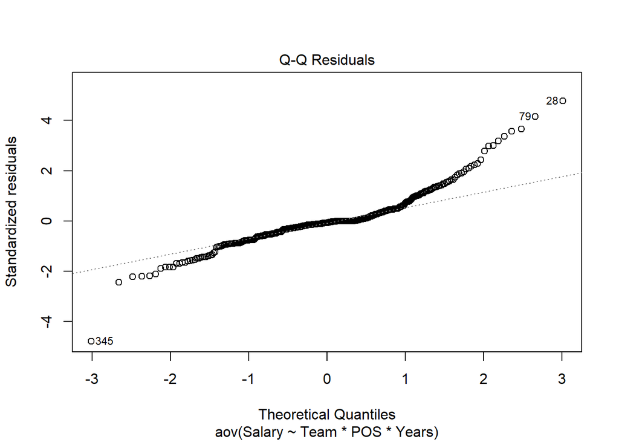

```r
plot(salary.aov, which = 2)
```

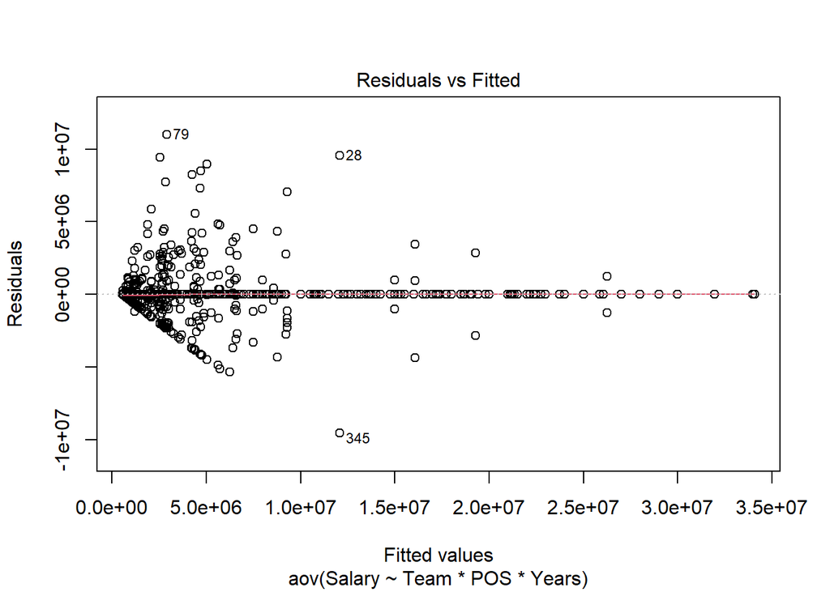

```r
plot(salary.aov, which=1)
```

#### Individual Category Residuals

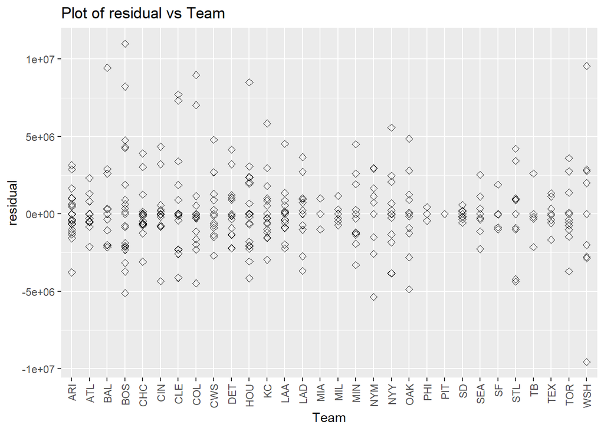

```r
library(ggplot2)
data$residual <- salary.aov$residuals
ggplot(data, aes(x=Team, y=residual)) +geom_point(size=2, shape=23)+
  labs(title = "Plot of residual vs Team")+theme(axis.text.x = element_text(angle = 90, vjust = 0.5, hjust=1))
```

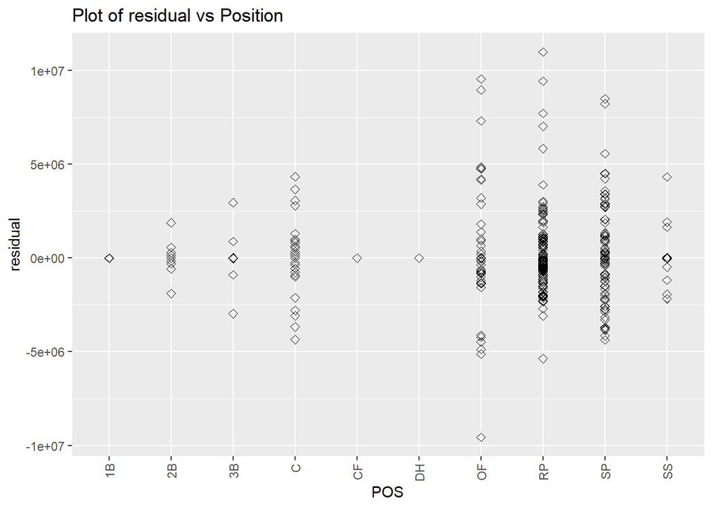

```r
ggplot(data, aes(x=POS, y=residual)) +geom_point(size=2, shape=23)+
  labs(title = "Plot of residual vs Position")+theme(axis.text.x = element_text(angle = 90, vjust = 0.5, hjust=1))
```

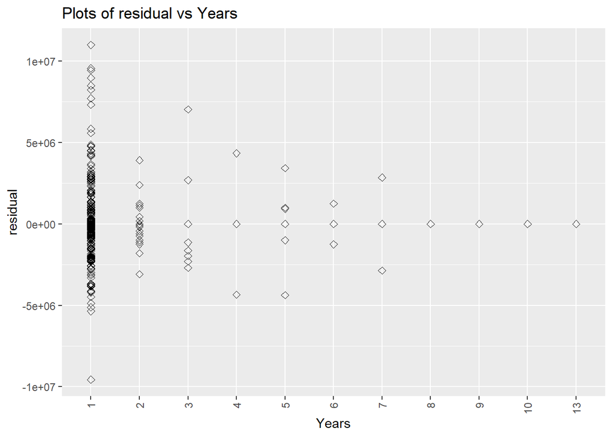

```r
ggplot(data, aes(x=Years, y=residual)) +geom_point(size=2, shape=23)+
  labs(title = "Plots of residual vs Years")+theme(axis.text.x = element_text(angle = 90, vjust = 0.5, hjust=1))
```